# Exploring the BRFSS data

## Setup

### Load packages

```r
library(ggplot2)
library(dplyr)
library(stringr)
load("brfss2013.RData")
```

## Part 1: Data

The Behavioral Risk Factor Surveillance System (BRFSS) survey is conducted by randomly selecting adult telephone users of landline and celluar. TAll selected participants are residential phone line users. The scope of the survey is all 50 states, the District of Columbia, Puerto Rico, Guam and American Samoa, Federated States of Micronesia, and Palau.

## Part 2: Research questions

**Research quesion 1:**

There is a saying that people with better health are more likely to marry. I would like to see if martial status has relations with health. After exploring the data set. I will use two variables, “marital” and “X_rfhlth”, which is “Marital Status” and “Adults with good or better health” respectively. Analysis result will be presented in a plot.

**Research quesion 2:**

According to my personal experience, I will stop craving greasy food, coffee, chocolate, and other not healthy food after I work out/exercise regularly. I will assume somehow exercise may help people to stop smoking or at least smoking less after exercise. I will find out if smoking and exercise have any correlations? I will use the following variables:

smokday2 — Frequency of Days Now Smoking

exerany2 — Exercise in Past 30 Days

strength — How many times did you do physical activities or exercises to STRENGTHEN your muscles?

sex — Respondents Sex.

**Research quesion 3:**

Exercise is one of effective ways to control blood sugar. In here, I would like to see how many people at age 18-65 with diabetes and with/without using insulin excercise regularly. I will use the following variables:

diabage2 — Age When Told Diabetic

diabete3 — Ever told) you have diabetes

sex — Respondents Sex

X_age65yr — Reported age in two age groups calculated variable

insulin — Now Taking Insulin

X_totinda — Leisure Time Physical Activity Calculated Variable

## Part 3: Exploratory data analysis

**Research quesion 1:**

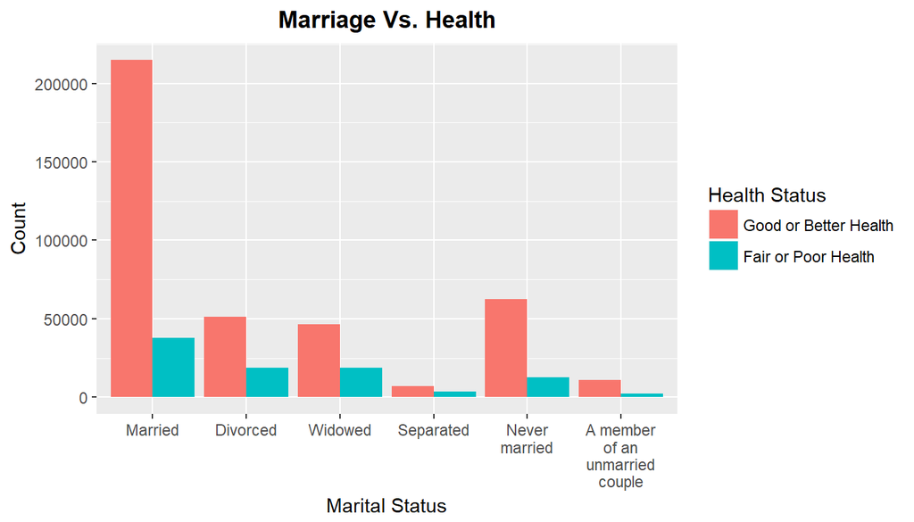

```r
plot_q1 <- brfss2013 %>%
  filter(!is.na(X_rfhlth), !is.na(marital)) %>%
  group_by(X_rfhlth, marital) %>%
  summarise(count=n())
ggplot(plot_q1, aes(x = marital, y = count, fill = X_rfhlth)) +
  geom_bar(stat = 'identity', position = 'dodge') +
  scale_x_discrete(labels = function(plot_q1) str_wrap(plot_q1, width = 10)) +
  ggtitle("Marriage Vs. Health") +
  theme(plot.title = element_text(lineheight=.8, face="bold", hjust = 0.5)) +
  ylab("Count") +
  xlab("Marital Status") +
  labs(fill = "Health Status")
```

From the above plot, people who are married do have better health than others who are not married.

**Research quesion 2:**

strength value and value label according to the codebook report: variable: EXERANY2, STRENGTH If value of EXERANY2 is not yes, the participants will need to answer further questions, SAS variable STRENGTH: 101 - 199 Times per week 201 - 299 Times per month 777 Don’t know / Not sure 888 Never  
999 Refused BLANK Not asked or Missing

```r
#select variables that are needed
plot_q2 <- brfss2013 %>%
  select(smokday2, exerany2, strength, sex) %>%
  filter(!is.na(smokday2))

sum(is.na(plot_q2$smokday2)) #ensure no NA value
```

```
## [1] 0
```

```r
head(plot_q2,5)
```

```
##     smokday2 exerany2 strength    sex
## 1 Not at all       No        0 Female
## 2  Some days       No        0 Female
## 3 Not at all       No        0   Male
## 4 Not at all      Yes      205 Female
## 5  Every day      Yes        0 Female
```

```r
#although some participantes answered no when asking if they workout regularly, they some activities to strength musules
plot_q2$stren_lab <-
  ifelse(is.na(plot_q2$strength) | plot_q2$strength == 0 & plot_q2$exerany2 != "Yes", "Not asked or Missing",
         ifelse(plot_q2$exerany2 == "No" & plot_q2$strength >= 101 & plot_q2$strength <= 199, "Times per week",
                ifelse(plot_q2$exerany2 == "No" & plot_q2$strength >= 201 & plot_q2$strength <= 299, "Times per month",
                       ifelse(plot_q2$exerany2 == "No" & plot_q2$strength >= 777 & plot_q2$strength < 888, "Don't know / Not sure",
                              ifelse(plot_q2$exerany2 == "No" & plot_q2$strength >= 888 & plot_q2$strength <= 999, "Never",
                                     ifelse(plot_q2$exerany2 == "No" & plot_q2$strength >= 999, "Refused",
                                            ifelse(plot_q2$exerany2 == "Yes", "Exercises",
                                                   "Not asked or Missing")))))))

head(plot_q2,5)
```

```
##     smokday2 exerany2 strength    sex            stren_lab
## 1 Not at all       No        0 Female Not asked or Missing
## 2  Some days       No        0 Female Not asked or Missing
## 3 Not at all       No        0   Male Not asked or Missing
## 4 Not at all      Yes      205 Female            Exercises
## 5  Every day      Yes        0 Female            Exercises
```

```r
#some participants did not answer the first question but do some activities to strength musules

plot_q2$stren_lab[is.na(plot_q2$stren_lab)] <-
  ifelse(plot_q2$strength >= 101 & plot_q2$strength <= 199, "Times per week",
                               ifelse(plot_q2$strength >= 201 & plot_q2$strength <= 299, "Times per month",
                                      ifelse(plot_q2$strength >= 777 & plot_q2$strength < 888, "Don't know / Not sure",
                                             ifelse(plot_q2$strength >= 888 & plot_q2$strength <= 999, "Never",
                                                    ifelse(plot_q2$strength >= 999, "Refused", "Not asked or Missing")))))
sum(is.na(plot_q2$stren_lab))
```

```
## [1] 8
```

```r
plot_q2 %>%
  group_by(smokday2, stren_lab, sex) %>%
  summarise(count=n())
```

```
## # A tibble: 32 x 4
## # Groups:   smokday2, stren_lab [?]
##     smokday2            stren_lab    sex count
##       <fctr>                <chr> <fctr> <int>
##  1 Every day            Exercises   Male 14274
##  2 Every day            Exercises Female 16452
##  3 Every day            Exercises   <NA>     1
##  4 Every day Not asked or Missing   Male  9522
##  5 Every day Not asked or Missing Female 12317
##  6 Every day Not asked or Missing   <NA>     1
##  7 Every day      Times per month   Male   626
##  8 Every day      Times per month Female   604
##  9 Every day       Times per week   Male   673
## 10 Every day       Times per week Female   690
## # ... with 22 more rows
```

exerany2 — During the past month, other than your regular job, did you participate in any physical activities or exercises such as running, calisthenics, golf, gardening, or walking for exercise?

```r
#define if this participants exercise no matter what form of the exercises
plot_q2 <- plot_q2 %>%
  mutate(exercise = ifelse(((smokday2 == "Every day" | smokday2 == "Some days") & stren_lab == "Not asked or Missing") |
                            (smokday2 == "Not at all" & stren_lab == "Not asked or Missing"), "No", "Yes"))


head(plot_q2, 5)
```

```
##     smokday2 exerany2 strength    sex            stren_lab exercise
## 1 Not at all       No        0 Female Not asked or Missing       No
## 2  Some days       No        0 Female Not asked or Missing       No
## 3 Not at all       No        0   Male Not asked or Missing       No
## 4 Not at all      Yes      205 Female            Exercises      Yes
## 5  Every day      Yes        0 Female            Exercises      Yes
```

```r
data <- plot_q2 %>%
  filter(!is.na(smokday2), !is.na(exercise), !is.na(sex)) %>%
  group_by(smokday2, exercise, sex) %>%
  summarise(count=n())
```

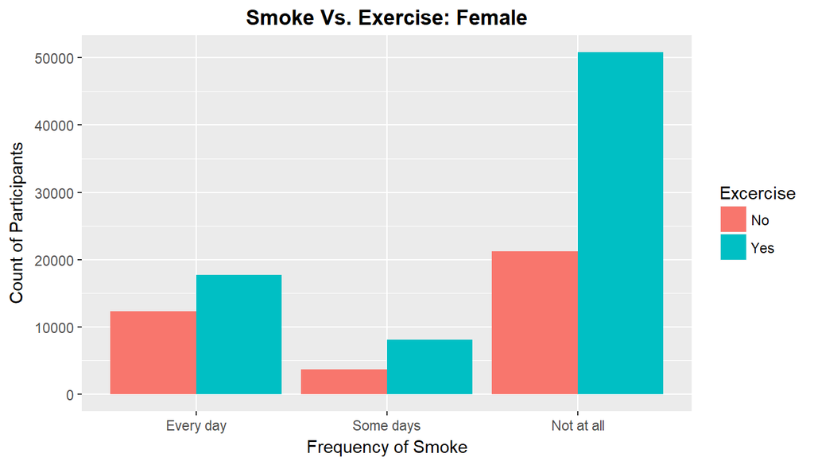

```r
#generate plot for male and female
data_female <- data[data$sex == "Female",]
data_male <- data[data$sex == "Male",]

plot_female <- ggplot(data_female, aes(x = smokday2, y = count, fill = exercise)) +
  geom_bar(stat = 'identity', position = 'dodge') +
  ggtitle("Smoke Vs. Exercise: Female") +
  theme(plot.title = element_text(lineheight=.8, face="bold", hjust = 0.5)) +
  ylab("Count of Participants") +
  xlab("Frequency of Smoke") +
  labs(fill = "Excercise")

plot_female
```

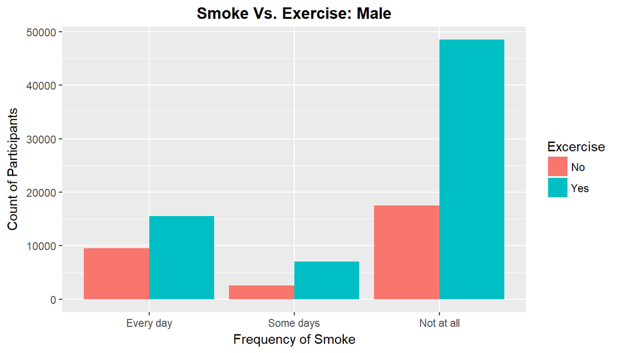

```r
plot_male <- ggplot(data_male, aes(x = smokday2, y = count, fill = exercise)) +
  geom_bar(stat = 'identity', position = 'dodge') +
  ggtitle("Smoke Vs. Exercise: Male") +
  theme(plot.title = element_text(lineheight=.8, face="bold", hjust = 0.5)) +
  ylab("Count of Participants") +
  xlab("Frequency of Smoke") +
  labs(fill = "Excercise")

plot_male
```

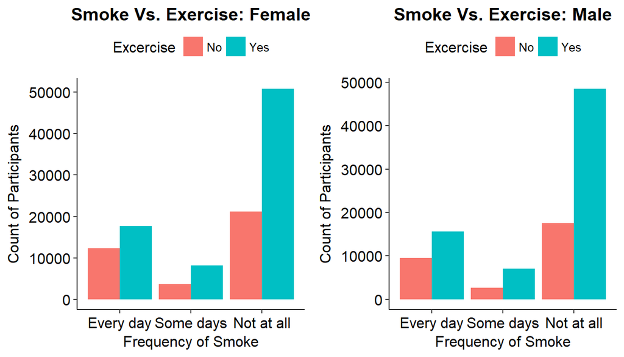

```r
#combine the above two plots side by side into one.

library(ggplot2)
library(ggpubr)
theme_set(theme_pubr())
ggarrange(plot_female, plot_male)
```

From the above analysis, tabacco usage does not have strong correlations with exercise. By saying that, doing exercise does not help people stop smoking, and people who smoke do exercise. However, the plot shows that there are more non-smokers who exercise than smokers.

**Research quesion 3:**

```r
#select variables that are needed
plot_q3_ori <- brfss2013 %>%
  filter(X_age65yr == "Age 18 to 64") %>%
  select(diabage2, diabete3, sex, X_age65yr, insulin, X_totinda)

head(plot_q3_ori, 5)
```

```
##   diabage2 diabete3    sex    X_age65yr insulin
## 1                No Female Age 18 to 64    <NA>
## 2                No Female Age 18 to 64    <NA>
## 3                No Female Age 18 to 64    <NA>
## 4                No Female Age 18 to 64    <NA>
## 5                No Female Age 18 to 64    <NA>
##                                          X_totinda
## 1 No physical activity or exercise in last 30 days
## 2                Had physical activity or exercise
## 3 No physical activity or exercise in last 30 days
## 4                Had physical activity or exercise
## 5                Had physical activity or exercise
```

```r
#here is my curiosity, the average and median age of diabetes diagnoses
plot_q3_diab <- plot_q3_ori %>%
  filter(diabete3 == "Yes")

head(plot_q3_diab, 5)
```

```
##   diabage2 diabete3    sex    X_age65yr insulin
## 1       55      Yes Female Age 18 to 64      No
## 2       64      Yes   Male Age 18 to 64      No
## 3       46      Yes Female Age 18 to 64      No
## 4       52      Yes Female Age 18 to 64      No
## 5               Yes Female Age 18 to 64     Yes
##                                          X_totinda
## 1 No physical activity or exercise in last 30 days
## 2 No physical activity or exercise in last 30 days
## 3 No physical activity or exercise in last 30 days
## 4                Had physical activity or exercise
## 5                Had physical activity or exercise
```

```r
print(paste("Average age of diabetes diagnoses:", mean(as.numeric(plot_q3_diab$diabage2), na.rm=TRUE)))
```

```
## [1] "Average age of diabetes diagnoses: 23.6393868087757"
```

```r
print(paste("Median age of diabetes diagnoses:", median(as.numeric(plot_q3_diab$diabage2), na.rm=TRUE)))
```

```
## [1] "Median age of diabetes diagnoses: 24"
```

```r
#get rid of some columns that not used anymore
plot_q3 <- plot_q3_diab %>%
  select(diabage2, sex, insulin, X_totinda)

head(plot_q3, 5)
```

```
##   diabage2    sex insulin                                        X_totinda
## 1       55 Female      No No physical activity or exercise in last 30 days
## 2       64   Male      No No physical activity or exercise in last 30 days
## 3       46 Female      No No physical activity or exercise in last 30 days
## 4       52 Female      No                Had physical activity or exercise
## 5          Female     Yes                Had physical activity or exercise
```

```r
plot_q3 <- plot_q3 %>%
  group_by(insulin, X_totinda) %>%
  summarise(count=n())

plot_q3
```

```
## # A tibble: 9 x 3
## # Groups:   insulin [?]
##   insulin                                        X_totinda count
##    <fctr>                                           <fctr> <int>
## 1     Yes                Had physical activity or exercise  3148
## 2     Yes No physical activity or exercise in last 30 days  2336
## 3     Yes                                             <NA>   356
## 4      No                Had physical activity or exercise  6464
## 5      No No physical activity or exercise in last 30 days  3893
## 6      No                                             <NA>   651
## 7    <NA>                Had physical activity or exercise  7176
## 8    <NA> No physical activity or exercise in last 30 days  4075
## 9    <NA>                                             <NA>   799
```

```r
# get rid of NA in columns insulin and X_totinda
plot_q3$insulin <- as.character(plot_q3$insulin)
plot_q3$insulin <- ifelse(is.na(plot_q3$insulin), "Not asked or Missing", plot_q3$insulin)
plot_q3$insulin <- factor(plot_q3$insulin)

plot_q3$X_totinda <- as.character(plot_q3$X_totinda)
plot_q3$X_totinda <- ifelse(is.na(plot_q3$X_totinda), "Not asked or Missing", plot_q3$X_totinda)
plot_q3$X_totinda <- factor(plot_q3$X_totinda)


plot_q3
```

```
## # A tibble: 9 x 3
## # Groups:   insulin [?]
##                insulin                                        X_totinda
##                 <fctr>                                           <fctr>
## 1                  Yes                Had physical activity or exercise
## 2                  Yes No physical activity or exercise in last 30 days
## 3                  Yes                             Not asked or Missing
## 4                   No                Had physical activity or exercise
## 5                   No No physical activity or exercise in last 30 days
## 6                   No                             Not asked or Missing
## 7 Not asked or Missing                Had physical activity or exercise
## 8 Not asked or Missing No physical activity or exercise in last 30 days
## 9 Not asked or Missing                             Not asked or Missing
## # ... with 1 more variables: count <int>
```

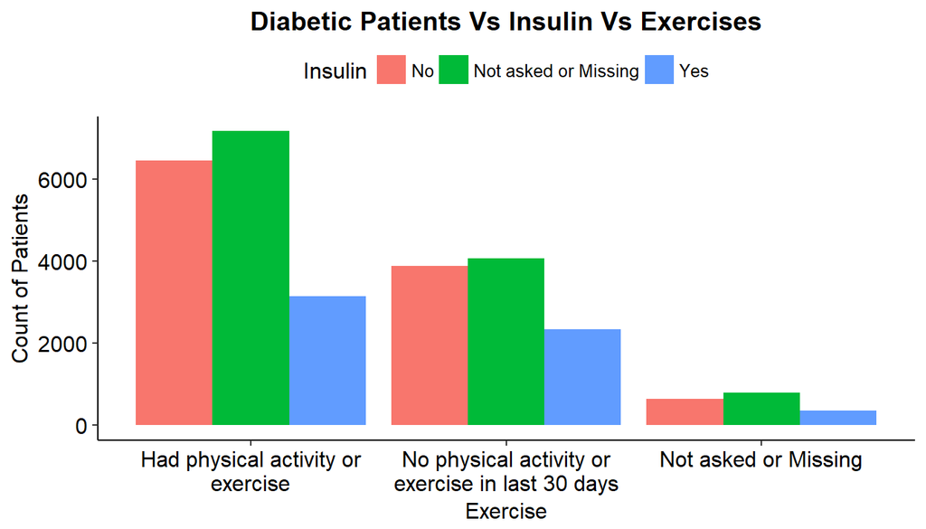

```r
#generage plot
ggplot(plot_q3, aes(x = X_totinda, y = count, fill = insulin)) +
  geom_bar(stat = 'identity', position = 'dodge') +
  ggtitle("Diabetic Patients Vs Insulin Vs Exercises") +
  theme(plot.title = element_text(lineheight=.8, face="bold", hjust = 0.5)) +
  ylab("Count of Patients") +
  xlab("Exercise") +
  labs(fill = "Insulin") +
  scale_x_discrete(labels = function(plot_q1) str_wrap(plot_q1, width = 30))
```